# normalizing.data

2025-07-15

```r
library(ggplot2)
library(caret)
library('ggpubr')
library(tidyverse)
```

### Normalizing Data

```r
cleanBreathData <- read.csv('cleanBreathData.csv')

bbMin <- min(cleanBreathData$breathingBeltRespiration)
bbMax <- max(cleanBreathData$breathingBeltRespiration)

sMin <- min(cleanBreathData$sensorRespiration)
sMax <- max(cleanBreathData$sensorRespiration)


normalBreathData <-
  cleanBreathData %>%
  mutate(norm_bb = ((breathingBeltRespiration - bbMin)/(bbMax- bbMin))) %>%
  mutate(norm_s = ((sensorRespiration - sMin)/(sMax - sMin)))
```

```r
shapiro.test(normalBreathData$norm_s)
```

```
##
##  Shapiro-Wilk normality test
##
## data:  normalBreathData$norm_s
## W = 0.96268, p-value < 2.2e-16
```

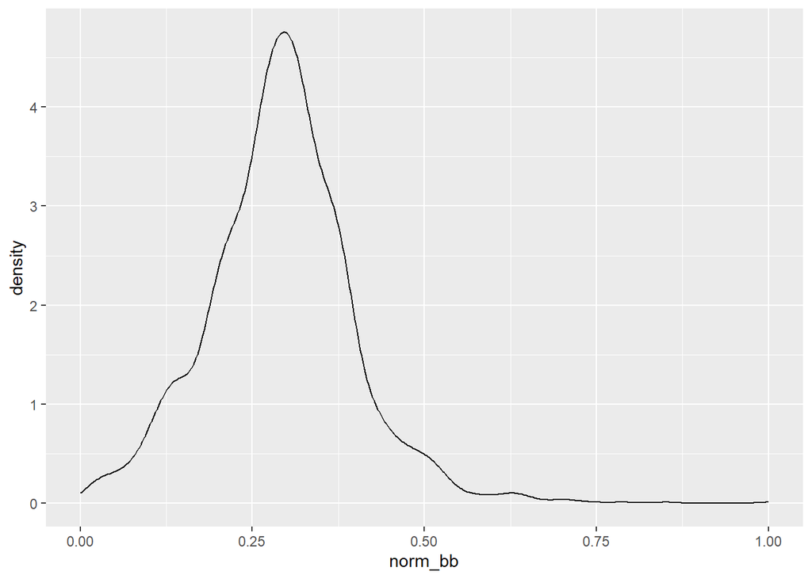

```r
ggplot(normalBreathData, aes(x = norm_bb)) +
  geom_density()
```

###Correlation between sensor respiration and percent error

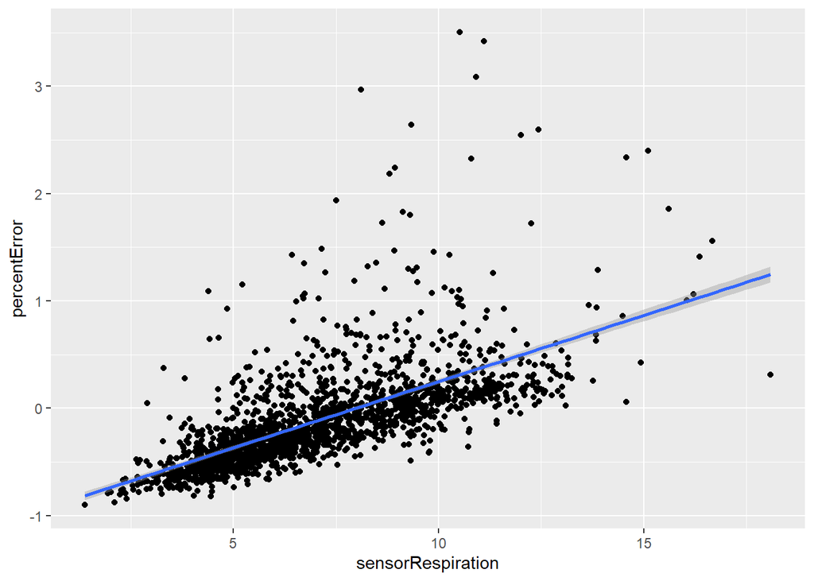

```r
breathPlot <- ggplot(cleanBreathData, aes(x = sensorRespiration, y= percentError)) +
  geom_point() +
  geom_smooth(method = 'lm')

breathPlot
```

Visualization suggests a positive correlation between sensor respiration and percent error. This might support lowering the upper bound to reduce percent error.

```r
cor.test(cleanBreathData$sensorRespiration, cleanBreathData$percentError, method = "pearson")
```

```
##
##  Pearson's product-moment correlation
##
## data:  cleanBreathData$sensorRespiration and cleanBreathData$percentError
## t = 37.537, df = 1813, p-value < 2.2e-16
## alternative hypothesis: true correlation is not equal to 0
## 95 percent confidence interval:
##  0.6345898 0.6864179
## sample estimates:
##       cor
## 0.6612923
```

The p-value of the Pearson supports correlation displayed on the visual.

```r
cor.test(cleanBreathData$sensorRespiration, cleanBreathData$percentError, method = "spearman")
```

```
##
##  Spearman's rank correlation rho
##
## data:  cleanBreathData$sensorRespiration and cleanBreathData$percentError
## S = 205027206, p-value < 2.2e-16
## alternative hypothesis: true rho is not equal to 0
## sample estimates:
##       rho
## 0.7942532
```

The p=value of the Spearman test also supports the correlation .

```r
model <- lm(percentError ~ sensorRespiration, data = cleanBreathData)

eq <- paste("y = ", format(coef(model)[1], digits = 2), " + ",
               format(coef(model)[2], digits = 2), "x")

print(eq)
```

```
## [1] "y =  -0.98  +  0.12 x"
```

Using the equation given, solve for breathing belt respiration.

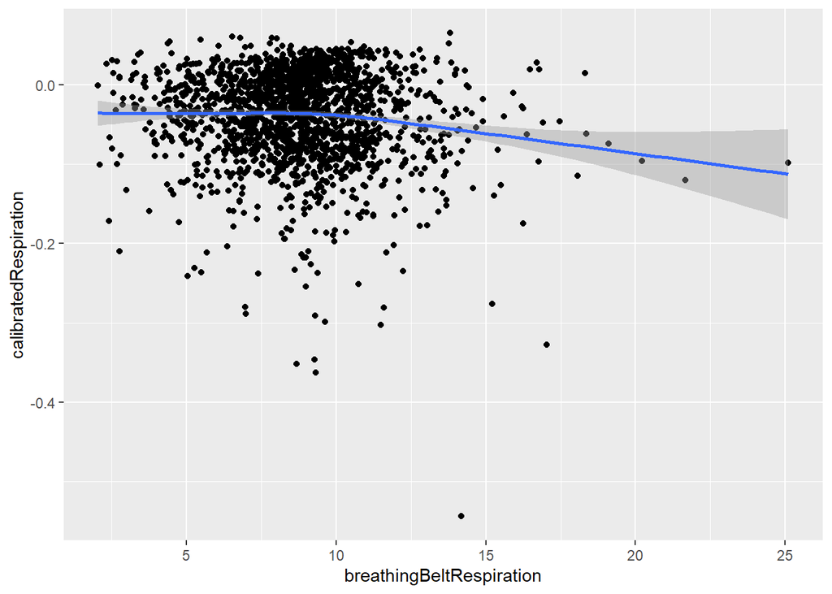

```r
calibratedBreathData <-
  cleanBreathData %>%
  mutate(calibratedRespiration = ((sensorRespiration * -0.12) + 0.98)/(-0.12 - sensorRespiration))

ggplot(calibratedBreathData, aes(x = breathingBeltRespiration, y = calibratedRespiration)) +
  geom_point() +
  geom_smooth()
```

Did not yield good correlation.

### Correlation between deviation and sensor respiration

```r
cor.test(cleanBreathData$sensorRespiration, cleanBreathData$deviation, method = "pearson")
```

```
##
##  Pearson's product-moment correlation
##
## data:  cleanBreathData$sensorRespiration and cleanBreathData$deviation
## t = -45.406, df = 1813, p-value < 2.2e-16
## alternative hypothesis: true correlation is not equal to 0
## 95 percent confidence interval:
##  -0.7502741 -0.7071674
## sample estimates:
##        cor
## -0.7294441
```

Pearson correlation test indicates correlation between sensor respiration and deviation

```r
cor.test(cleanBreathData$sensorRespiration, cleanBreathData$deviation, method = "spearman")
```

```
##
##  Spearman's rank correlation rho
##
## data:  cleanBreathData$sensorRespiration and cleanBreathData$deviation
## S = 1744109596, p-value < 2.2e-16
## alternative hypothesis: true rho is not equal to 0
## sample estimates:
##        rho
## -0.7502306
```

Spearman test also indicates correlation between sensor respiration and deviation.

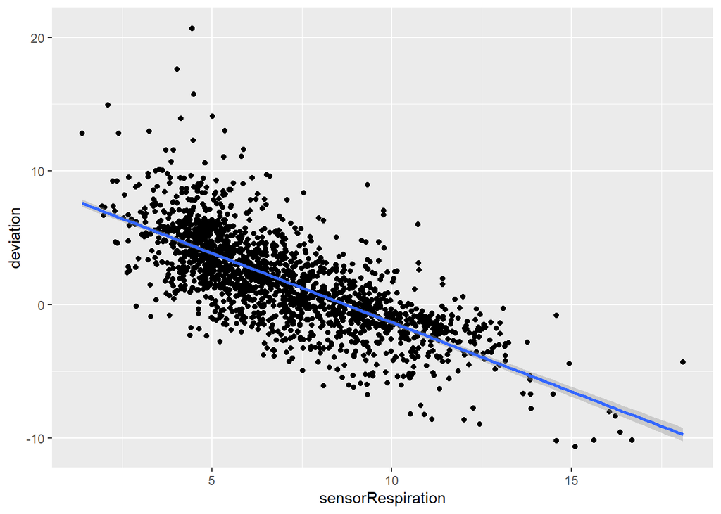

```r
ggplot(cleanBreathData, aes(x = sensorRespiration, y = deviation)) +
  geom_point() +
  geom_smooth(method = "lm")
```

Negative correlation supports further reducing respiration range.

```r
dModel <- lm(deviation ~ sensorRespiration, data = cleanBreathData)

eq <- paste("y = ", format(coef(dModel)[1], digits = 2), " + ",
               format(coef(dModel)[2], digits = 2), "x")

print(eq)
```

```
## [1] "y =  9  +  -1 x"
```

This equation would indicates that real is always 9, so not helpful!

###Differences between the Two Sets

```r
bbRange <- range(cleanBreathData$breathingBeltRespiration)
bbRange
```

```
## [1]  2.043597 25.104603
```

```r
sRange <- range(cleanBreathData$sensorRespiration)
sRange
```

```
## [1]  1.377921 18.097500
```

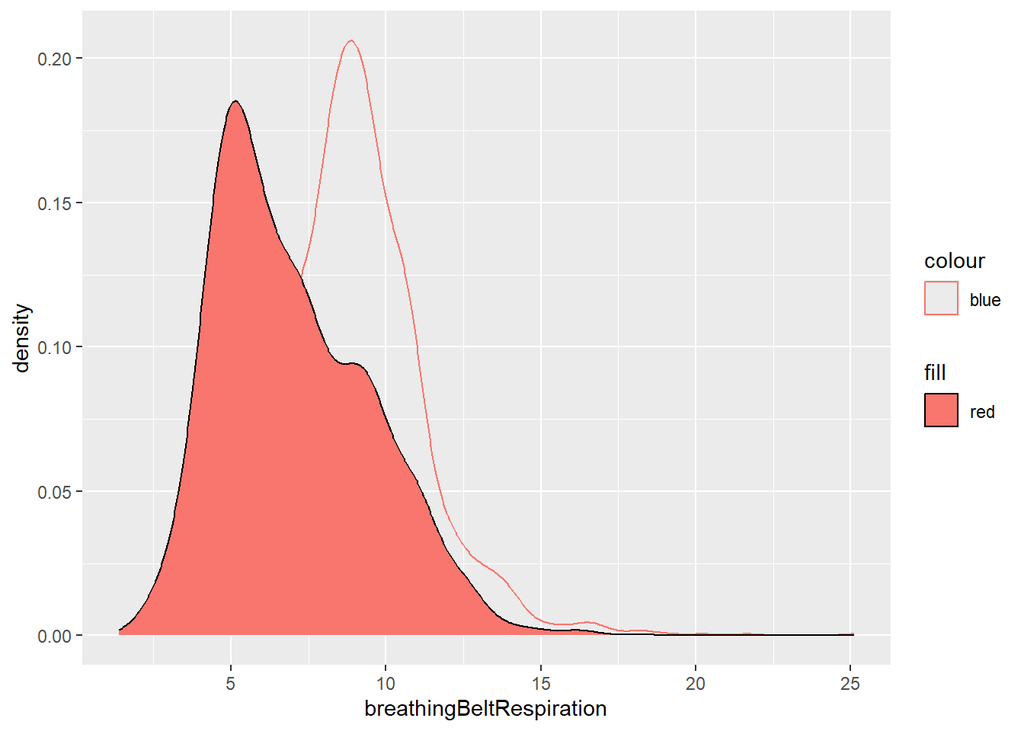

```r
ggplot(cleanBreathData, aes(x = breathingBeltRespiration)) +
  geom_density(aes(color = 'blue')) +
  geom_density(aes(x = sensorRespiration, fill = 'red'))
```

```r
median(cleanBreathData$breathingBeltRespiration)
```

```
## [1] 8.789062
```

```r
quantile(cleanBreathData$breathingBeltRespiration)
```

```
##        0%       25%       50%       75%      100%
##  2.043597  7.311129  8.789062 10.131713 25.104603
```

Suggestion: change respiration range to 7 - 11 bpm.

###Changed Range

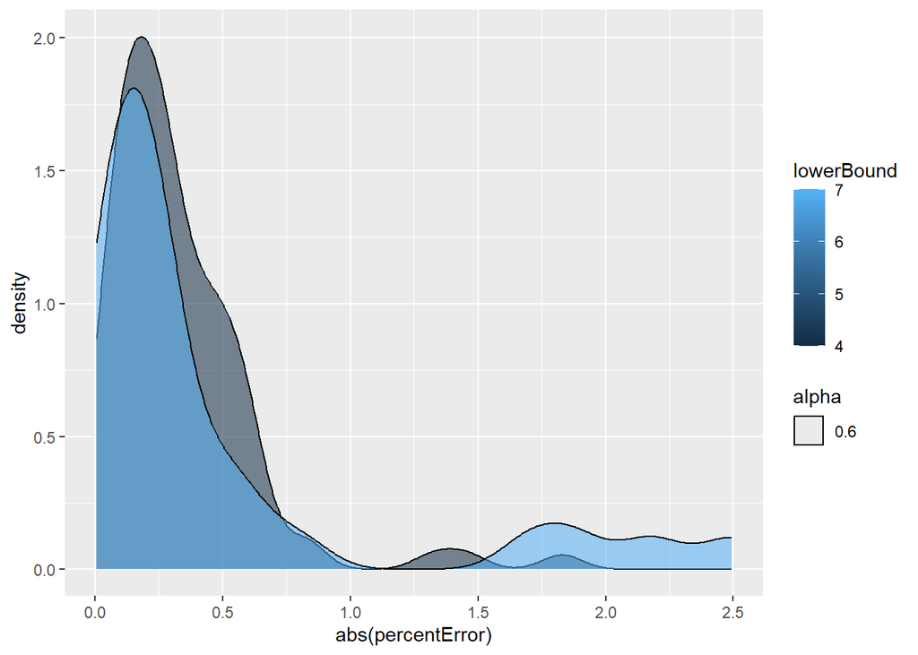

```r
justTwo <-
  cleanBreathData %>%
  filter(height == 2) %>%
  mutate(lowerBound = 4, upperBound = 30) %>%
  select(breathingBeltRespiration, sensorRespiration, percentError, deviation, lowerBound, upperBound)

joined2 <- read.csv('joined-h2-d0.6-front-v2.csv')

cutRange <-
  joined2 %>%
  select(breathingBeltRespiration, sensorRespiration) %>%
  mutate(lowerBound = 7, upperBound = 11) %>%
  mutate(percentError = ((sensorRespiration - breathingBeltRespiration)/ breathingBeltRespiration),
         deviation = breathingBeltRespiration - sensorRespiration)

twovtwo <- rbind(justTwo, cutRange)

ggplot(twovtwo, aes(x = abs(percentError), group = lowerBound)) +
  geom_density(aes(fill = lowerBound, alpha = 0.6))
```

```r
median(abs(cutRange$percentError))
```

```
## [1] 0.211546
```

```r
median(abs(justTwo$percentError))
```

```
## [1] 0.2557324
```

```r
mean(abs(cutRange$percentError))
```

```
## [1] 0.4769437
```

```r
mean(abs(justTwo$percentError))
```

```
## [1] 0.33055
```

Errors seem to occur at the greatest scale when the real respiration rate is below the lower bound.

```r
outliers <-
  twovtwo %>%
    filter(abs(percentError) > 1.0)

head(outliers)
```

```
##   breathingBeltRespiration sensorRespiration percentError deviation lowerBound
## 1                 3.558719          8.270737     1.324077 -4.712018          4
## 2                 4.021448          9.877938     1.456314 -5.856491          4
## 3                 3.225806          9.126942     1.829352 -5.901135          4
## 4                 2.600000          9.082800     2.493384 -6.482800          7
## 5                 3.100000          8.384950     1.704823 -5.284950          7
## 6                 3.100000          8.945228     1.885557 -5.845228          7
##   upperBound
## 1         30
## 2         30
## 3         30
## 4         11
## 5         11
## 6         11
```

No instances exist where real respiration is above the upper bound. Try adjusting the lower bound to 2 and the upper bound to 11.

```r
overOut <-
  twovtwo %>%
  filter(breathingBeltRespiration > upperBound | breathingBeltRespiration < lowerBound)

head(overOut)
```

```
##   breathingBeltRespiration sensorRespiration percentError  deviation lowerBound
## 1                 3.558719          6.461604    0.8157107 -2.9028851          4
## 2                 3.558719          8.270737    1.3240771 -4.7120181          4
## 3                 3.627570          5.525700    0.5232512 -1.8981303          4
## 4                 2.994012          3.819279    0.2756390 -0.8252665          4
## 5                 3.225806          9.126942    1.8293519 -5.9011353          4
## 6                 3.937008          7.193669    0.8271921 -3.2566616          4
##   upperBound
## 1         30
## 2         30
## 3         30
## 4         30
## 5         30
## 6         30
```

```r
max(twovtwo$breathingBeltRespiration)
```

```
## [1] 13.36303
```

```r
quantile(twovtwo$breathingBeltRespiration)
```

```
##        0%       25%       50%       75%      100%
##  2.600000  6.030150  8.356546  9.900000 13.363029
```

### 4-11 range

```r
joined3 <- read.csv('joined-h2-d0.6-front-v3.csv')

newRange <-
  joined3 %>%
  select(breathingBeltRespiration, sensorRespiration) %>%
  mutate(lowerBound = 4, upperBound = 11) %>%
  mutate(range = '4-11') %>%
  mutate(percentError = ((sensorRespiration - breathingBeltRespiration)/ breathingBeltRespiration),
         deviation = breathingBeltRespiration - sensorRespiration)

cutRange <-
  cutRange %>%
  mutate(range = '7-11')

justTwo <-
  justTwo %>%
  mutate(range = '4-30')

moreRanges <- rbind(newRange, cutRange)

moreRanges <- rbind(moreRanges, justTwo)
```

The range of 4-11 performed better than both 4-30 and 7-11 in terms of percent error.

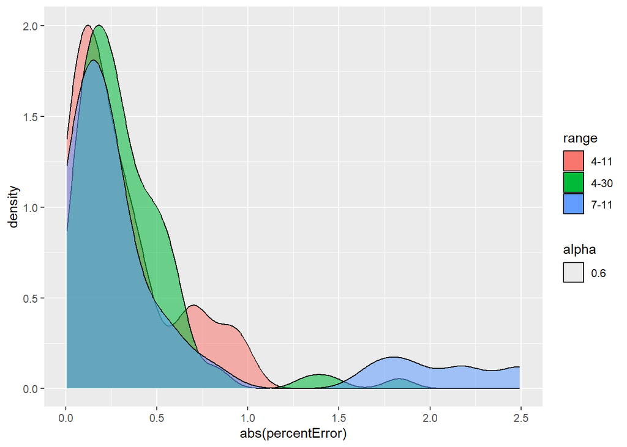

```r
ggplot(moreRanges, aes(x = abs(percentError), group = range)) +
  geom_density(aes(fill = range, alpha = 0.6))
```

```r
res <- moreRanges %>%
  group_by(range) %>%
  summarize(median(abs(percentError)), mean(abs(percentError)))

head(res)
```

```
## # A tibble: 3 × 3
##   range `median(abs(percentError))` `mean(abs(percentError))`
##   <chr>                       <dbl>                     <dbl>
## 1 4-11                        0.184                     0.291
## 2 4-30                        0.256                     0.331
## 3 7-11                        0.212                     0.477
```

Outliers seem to occur when real respiration is below the lower bound, again. Try adjusting to 2 to 11.

```r
outlyingPatterns <-
  newRange %>%
  arrange(desc(abs(percentError)))

head(outlyingPatterns)
```

```
##   breathingBeltRespiration sensorRespiration lowerBound upperBound range
## 1                      4.0          7.778974          4         11  4-11
## 2                      3.6          6.883865          4         11  4-11
## 3                      3.0          5.224504          4         11  4-11
## 4                      2.7          4.552918          4         11  4-11
## 5                      3.1          5.140835          4         11  4-11
## 6                      8.6          4.785248          4         11  4-11
##   percentError deviation
## 1    0.9447436 -3.778974
## 2    0.9121846 -3.283865
## 3    0.7415013 -2.224504
## 4    0.6862658 -1.852918
## 5    0.6583338 -2.040835
## 6   -0.4435758  3.814752
```

```r
cor.test(newRange$sensorRespiration, newRange$breathingBeltRespiration, method = "pearson")
```

```
##
##  Pearson's product-moment correlation
##
## data:  newRange$sensorRespiration and newRange$breathingBeltRespiration
## t = 5.577, df = 25, p-value = 8.444e-06
## alternative hypothesis: true correlation is not equal to 0
## 95 percent confidence interval:
##  0.5084116 0.8765640
## sample estimates:
##       cor
## 0.7445717
```

Pearson correlation test supports correlation!

```r
cor.test(newRange$sensorRespiration, newRange$breathingBeltRespiration, method = "spearman")
```

```
##
##  Spearman's rank correlation rho
##
## data:  newRange$sensorRespiration and newRange$breathingBeltRespiration
## S = 1191.7, p-value = 0.0003606
## alternative hypothesis: true rho is not equal to 0
## sample estimates:
##       rho
## 0.6362387
```

Spearman correlation supports correlation.

```r
calModel <- lm(sensorRespiration ~ breathingBeltRespiration, data = newRange)

eq <- paste("y = ", format(coef(calModel)[1], digits = 2), " + ",
               format(coef(calModel)[2], digits = 2), "x")

print(eq)
```

```
## [1] "y =  3.3  +  0.51 x"
```

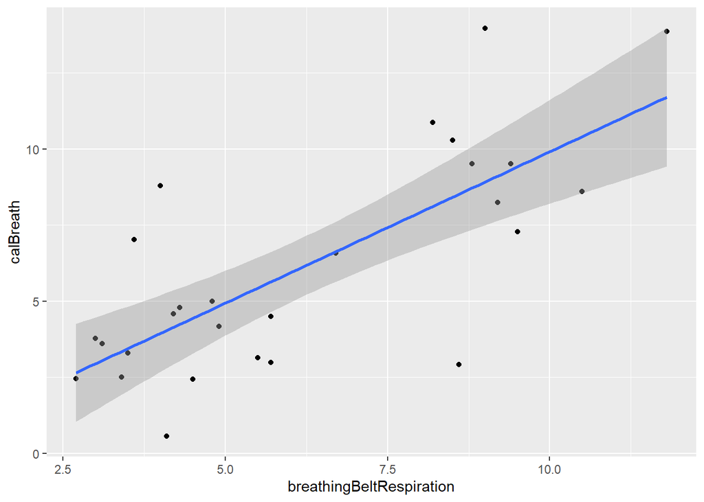

```r
calibratedData <-
  newRange %>%
  mutate(calBreath = (sensorRespiration - 3.3)/0.51)

ggplot(calibratedData, aes(x = breathingBeltRespiration, y = calBreath)) +
  geom_point() +
  geom_smooth(method = 'lm')
```

```r
head(calibratedData)
```

```
##   breathingBeltRespiration sensorRespiration lowerBound upperBound range
## 1                     11.8         10.370454          4         11  4-11
## 2                      8.2          8.840368          4         11  4-11
## 3                      9.5          7.015007          4         11  4-11
## 4                      8.6          4.785248          4         11  4-11
## 5                      8.5          8.549125          4         11  4-11
## 6                      9.0         10.417089          4         11  4-11
##   percentError   deviation calBreath
## 1 -0.121147947  1.42954578 13.863636
## 2  0.078093670 -0.64036809 10.863467
## 3 -0.261578188  2.48499279  7.284328
## 4 -0.443575833  3.81475216  2.912251
## 5  0.005779456 -0.04912538 10.292403
## 6  0.157454317 -1.41708885 13.955076
```

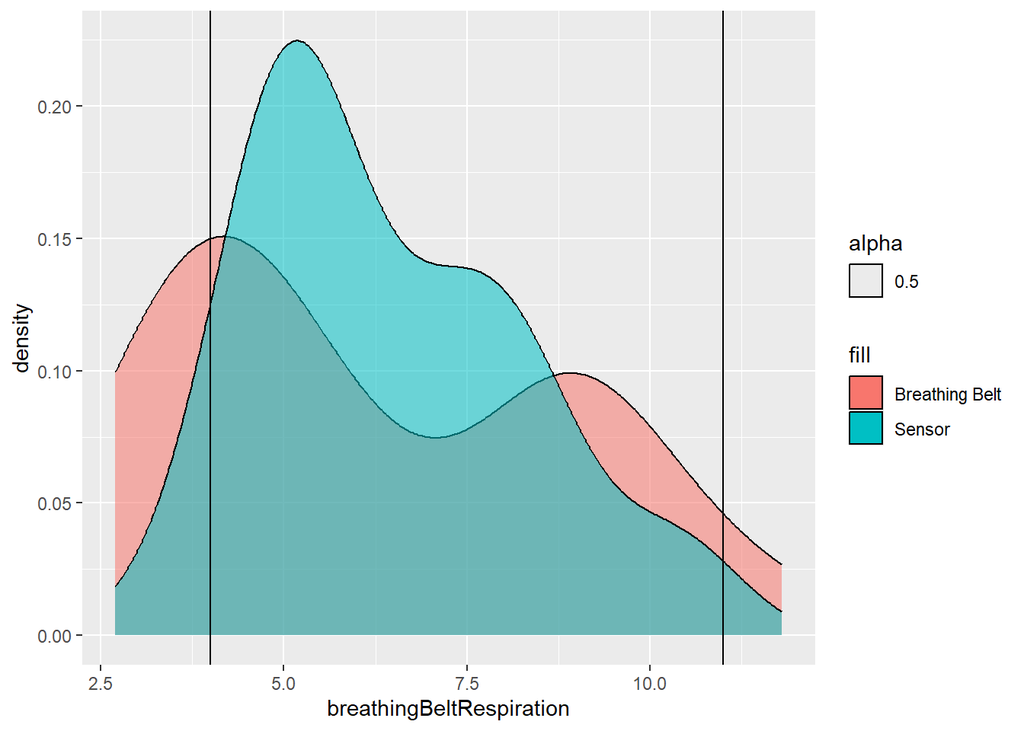

```r
ggplot(newRange, aes(x = breathingBeltRespiration)) +
  geom_density(aes(fill = 'Breathing Belt', alpha = 0.5)) +
  geom_density(aes(x = sensorRespiration, fill = 'Sensor', alpha = 0.5)) +
  geom_vline(aes(xintercept = lowerBound)) +
  geom_vline(aes(xintercept = upperBound))
```

```r
joined4 <- read.csv('joined-h2-d0.6-front-v4.csv')

range4 <-
  joined4 %>%
  select(breathingBeltRespiration, sensorRespiration) %>%
  mutate(lowerBound = 2, upperBound = 11) %>%
  mutate(range = '2-11') %>%
  mutate(percentError = ((sensorRespiration - breathingBeltRespiration)/ breathingBeltRespiration),
         deviation = breathingBeltRespiration - sensorRespiration)

moreRanges <- rbind(moreRanges, range4)

cor.test(range4$sensorRespiration, range4$breathingBeltRespiration, method = "pearson")
```

```
##
##  Pearson's product-moment correlation
##
## data:  range4$sensorRespiration and range4$breathingBeltRespiration
## t = 5.8072, df = 28, p-value = 3.078e-06
## alternative hypothesis: true correlation is not equal to 0
## 95 percent confidence interval:
##  0.5164199 0.8682279
## sample estimates:
##       cor
## 0.7391669
```

p-value of Pearson correlation test indicates correlation.

```r
res <- moreRanges %>%
  group_by(range) %>%
  summarize(median(abs(percentError)), mean(abs(percentError)))

head(res)
```

```
## # A tibble: 4 × 3
##   range `median(abs(percentError))` `mean(abs(percentError))`
##   <chr>                       <dbl>                     <dbl>
## 1 2-11                        0.114                     0.155
## 2 4-11                        0.184                     0.291
## 3 4-30                        0.256                     0.331
## 4 7-11                        0.212                     0.477
```

2-11 performed more accurately than the other ranges.

```r
checkOutlier <-
  range4 %>%
  arrange(desc(abs(percentError)))

head(checkOutlier)
```

```
##   breathingBeltRespiration sensorRespiration lowerBound upperBound range
## 1                      8.3          3.597973          2         11  2-11
## 2                      8.4          5.080049          2         11  2-11
## 3                      3.8          5.010721          2         11  2-11
## 4                      5.2          6.828885          2         11  2-11
## 5                      5.6          7.004680          2         11  2-11
## 6                      5.1          6.351162          2         11  2-11
##   percentError deviation
## 1   -0.5665093  4.702027
## 2   -0.3952323  3.319951
## 3    0.3186109 -1.210721
## 4    0.3132472 -1.628885
## 5    0.2508357 -1.404680
## 6    0.2453259 -1.251162
```

```r
max(range4$breathingBeltRespiration)
```

```
## [1] 9.7
```

```r
quantile(moreRanges$breathingBeltRespiration)
```

```
##        0%       25%       50%       75%      100%
##  2.600000  5.506216  7.450000  9.510307 13.363029
```

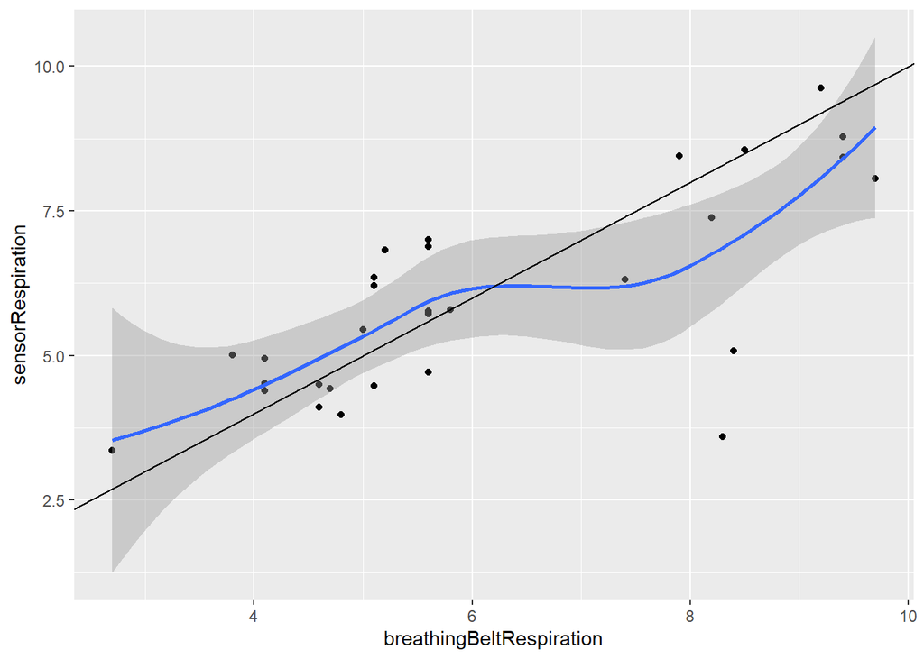

```r
ggplot(range4, aes(x = breathingBeltRespiration, y = sensorRespiration)) +
  geom_point() +
  geom_smooth() +
  geom_abline(aes(intercept = 0, slope = 1))
```

We could probably lower the upper bound even further. To a certain extent, we don’t really care too much about the higher respiration rates.

Higher percent errors occurred within range, could be related to time-outs. ### 0.8m

```r
joinedd8 <- read.csv('joined-h2-d0.8-front.csv')

d8 <-
  joinedd8 %>%
  select(breathingBeltRespiration, sensorRespiration) %>%
  mutate(lowerBound = 2, upperBound = 11) %>%
  mutate(range = '2-11') %>%
  mutate(percentError = ((sensorRespiration - breathingBeltRespiration)/ breathingBeltRespiration),
         deviation = breathingBeltRespiration - sensorRespiration)
```

```r
cor.test(d8$sensorRespiration, d8$breathingBeltRespiration, method = "pearson")
```

```
##
##  Pearson's product-moment correlation
##
## data:  d8$sensorRespiration and d8$breathingBeltRespiration
## t = -0.99051, df = 27, p-value = 0.3307
## alternative hypothesis: true correlation is not equal to 0
## 95 percent confidence interval:
##  -0.5181943  0.1924625
## sample estimates:
##        cor
## -0.1872516
```

No significant correlation. ###Can upper bound pose the same issues as the lower bound?

### Performing more tests with 2-11 Range